# Mason Analysis

Mason Wong, Eva Yin, Zhuolin Jiang, Matthew Shu

14/05/2022

$\newcommand{\hd}[1]{{\underline{\smash{\large\text{#1}}}}}$

# Our Data

We observe the data and see a quick overview of it.

```r
# a quick look at the data and it's columns
data = read.csv("../data/seatbelt_group_14.csv", header = TRUE, stringsAsFactors = TRUE)
names(data)
```

```
##  [1] "state"      "year"       "miles"      "fatalities" "seatbelt"
##  [6] "speed65"    "speed70"    "drinkage"   "alcohol"    "income"
## [11] "age"        "enforce"
```

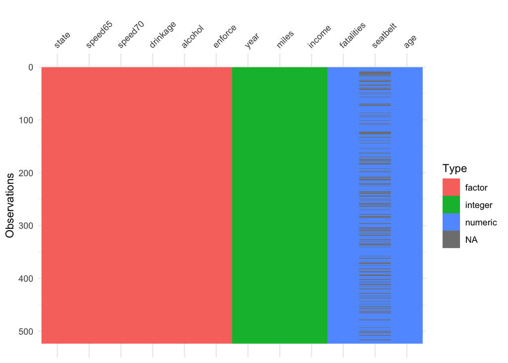

```r
vis_dat(data)
```

```r
str(data)
```

```
## 'data.frame':    523 obs. of  12 variables:
##  $ state     : Factor w/ 35 levels "AK","AL","AR",..: 11 8 11 6 11 15 15 24 1 33 ...
##  $ year      : int  1989 1990 1995 1993 1991 1985 1995 1986 1989 1985 ...
##  $ miles     : int  75705 3407 85384 32718 73005 70844 94189 33806 3887 13269 ...
##  $ fatalities: num  0.0216 0.0141 0.0174 0.0171 0.019 ...
##  $ seatbelt  : num  0.388 0.49 0.507 0.53 0.456 ...
##  $ speed65   : Factor w/ 2 levels "no","yes": 2 2 2 2 2 1 2 1 1 1 ...
##  $ speed70   : Factor w/ 2 levels "no","yes": 1 1 2 1 1 1 1 1 1 1 ...
##  $ drinkage  : Factor w/ 2 levels "no","yes": 2 2 2 2 2 2 2 2 2 2 ...
##  $ alcohol   : Factor w/ 2 levels "no","yes": 1 1 1 1 1 1 1 1 1 1 ...
##  $ income    : int  16466 25646 21696 22117 17930 15322 25135 15526 19970 11592 ...
##  $ age       : num  33.6 36.9 34.4 34.6 34 ...
##  $ enforce   : Factor w/ 3 levels "no","primary",..: 3 3 3 3 3 1 3 3 1 1 ...
```

```r
# Treat year as a factor variable
data$year = as.factor(data$year)

# obtain the percentage of missing data in the seatbelt variable
n_missing = sum(apply(is.na(data), 1, sum))
prop_n_missing = n_missing/nrow(data)
```

There are 12 variables.

- **The response variable** : fatalities (numerical)
- **The predictor variables** : These include…
  - year, miles, seatbelt, income and age (numerical variables)
  - state, speed65, speed70, drinkage, alcohol and enforce (categorical variables)

We also notice there to be lots of NA’s for the variable seatbelt. In fact, 24.47% of our data is missing for the `seatbelt` column. We look at how these NA’s tend to be distributed:

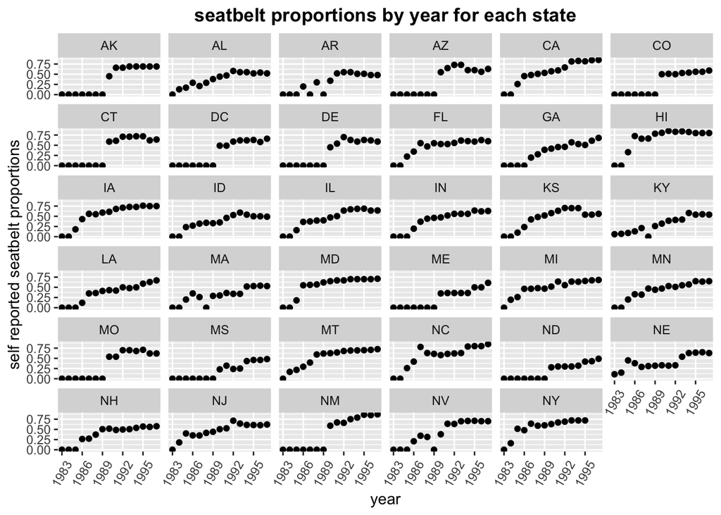

```r
# a temporary data frame, made to observe the NA's specifically across each state at each year
temp = data %>%
  dplyr::select(state, year, seatbelt) %>%
  group_by(year) %>%
  arrange(year) %>%
  arrange(state)

# for the NA's replace them with zeroes
temp = temp %>% mutate(seatbelt.no.na = case_when(is.na(seatbelt) ~ 0, TRUE ~ seatbelt))

# define function for below
every_nth = function(n) {
  return(function(x) {x[c(TRUE, rep(FALSE, n - 1))]})
}
# observe the plot of NA's by year and state
temp %>% ggplot(. , aes(x = factor(year), y = seatbelt.no.na)) +
  geom_point() +
  theme(axis.text.x = element_text(angle = 60, vjust = 0.5)) +
  scale_x_discrete(breaks = every_nth(n = 3)) +
  xlab('year') +
  ylab('self reported seatbelt proportions') +
  facet_wrap(~state) +
  ggtitle("seatbelt proportions by year for each state") +
  theme(plot.title = element_text(hjust = 0.5, face = 'bold'))
```

We have taken the liberty of **replacing the NA’s** with 0 and plotting them (albeit, grouping by state!) We see that the missing information tends to be in the earlier years. There are some instances when you have an NA in the middle of your data (e.g for KY we have an NA value in 1988 or for MA we have an NA value in 1988)

We also want to visually observe the distribution of fatalities by state. This is because there are too many factors (35) in the variable state alone, so we perform the visual analysis here

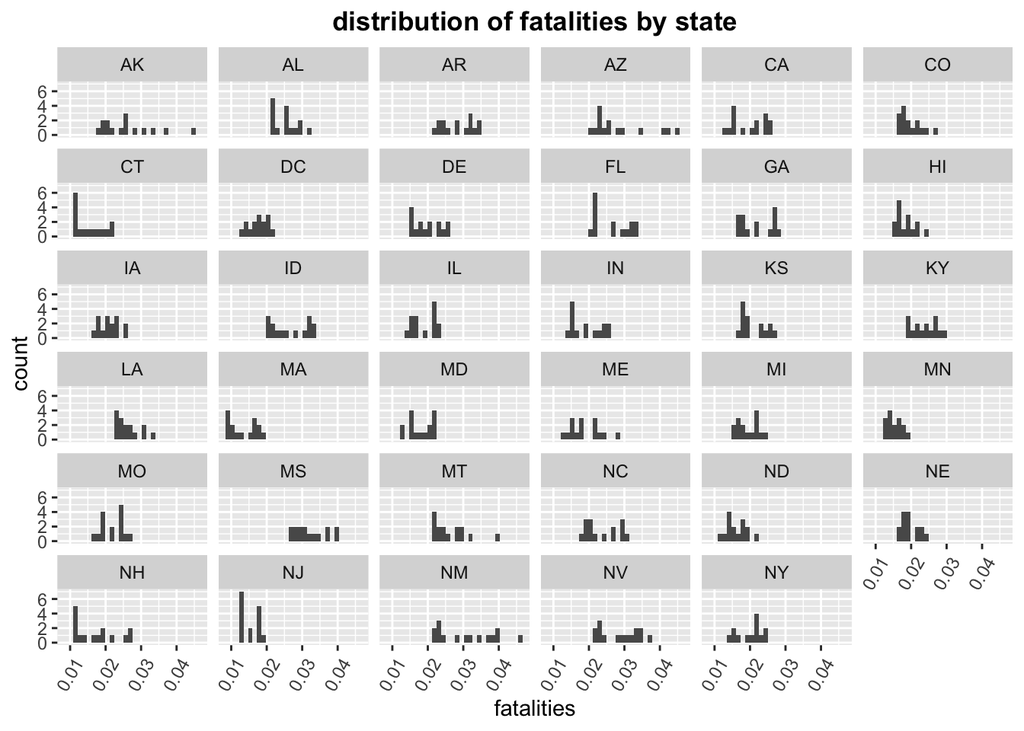

```r
data %>%
  dplyr::select(state, fatalities) %>%
  ggplot(. , aes(x = fatalities)) +
  geom_histogram() +
  theme(axis.text.x = element_text(angle = 60, vjust = 0.5)) +
  facet_wrap(~state) +
  ggtitle("distribution of fatalities by state") +
  theme(plot.title = element_text(hjust = 0.5, face = 'bold'))
```

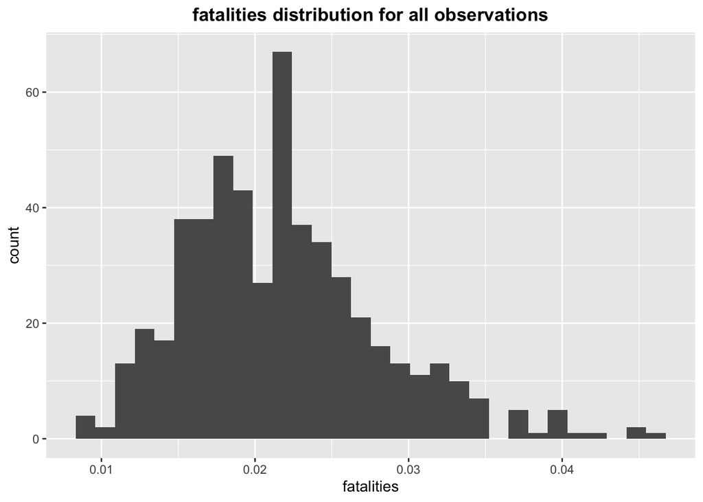

```r
data %>%
  dplyr::select(fatalities) %>%
  ggplot(. , aes(x = fatalities)) +
  geom_histogram() +
  ggtitle("fatalities distribution for all observations") +
  theme(plot.title = element_text(hjust = 0.5, face = 'bold'))
```

It seems like that the distribution of fatalities is very different by state alone.

```r
# TODO: delete
#The final thing we have taken the liberty of doing is re-label the states according to 5 general geographical locations. This reduces the number of levels we have for the variable `state` from 35 to 5. We the new levels: `group1`, `group2`, `group3`,`group4` and `group5`.

#We can now observe the distribution of fatalities by each geographic location:
#group1 = c('ME', 'NH', 'MA', 'CT', 'NY', 'NJ', 'DE', 'MD', 'DC')
#group2 = c('MN', 'MI', 'IA', 'IL', 'IN', 'MO', 'KY')
#group3 = c('AR', 'LA', 'MS', 'AL', 'GA', 'FL', 'NC')
#group4 = c('ID', 'MT', 'ND', 'CO', 'NE', 'KS')
#group5 = c('CA', 'NV', 'AZ', 'NM', 'AK', 'HI')
#
## make a copy of the raw data first
#data_grouped = data
#data_grouped$state = as.character(data_grouped$state)
#
#data_grouped = data_grouped %>% mutate(state = case_when(
#  state %in% group1 ~ 'group1',
#  state %in% group2 ~ 'group2',
#  state %in% group3 ~ 'group3',
#  state %in% group4 ~ 'group4',
#  state %in% group5 ~ 'group5'))
#
#data_grouped$state = as.factor(data_grouped$state)
#
#data_grouped %>%
#  dplyr::select(state, fatalities) %>%
#  ggplot(. , aes(x = fatalities)) +
#  geom_histogram() +
#  theme(axis.text.x = element_text(angle = 60, vjust = 0.5)) +
#  facet_wrap(~state) +
#  ggtitle("distribution of fatalities by geographic location") +
#  theme(plot.title = element_text(hjust = 0.5, face = 'bold'))
```

$\hd{Potential multicollinearity}$

Next we want to notice if there are any variables which show High collinearity. We can assess this with using the funtion `ggpairs()`

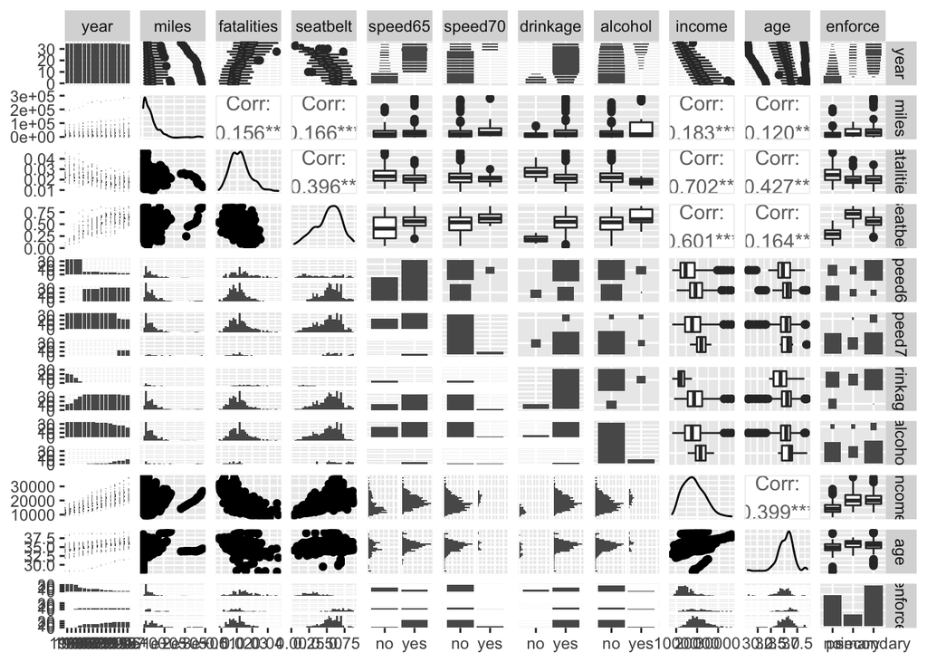

```r
data %>%
  dplyr::select(-state) %>%
  ggpairs()
```

We revisit multicollinearity when we go to our coarse grain model building and see if there is any serious multicollinearity which needs to be addressed.

# Domain knowledge

# Coarse grain model building

To build our models, we consider 2 data frames:

1. `data`: With this one we assume that we will not use the `seatbelt` variable at all and disregard it
2. `data.noNa`: a data frame where we have deleted all the **NA** rows . This is a case of listwise-deletion. This may be effective if time is not a huge predictor of fatalities.

```r
# get vector that has a row with NA
rows_with_na = apply(is.na(data), 1, sum)
data.noNa = data[!rows_with_na, ]
```

We now consider a couple models which we build with a forward, backward and bidirectional approach. For the first set of our models we focus on using the data set `data` excluding the variable of `seatbelt` completely. For the second set of our models, we will focus on the `data.noNa` data set

$\hd{Using the `data` data set}$

We use the original `data` data set excluding the `seatbelt` covariate due to the nature of the `NA`

```r
# the data set we use for our models
no_seatbelt_data = data %>% dplyr::select(-seatbelt)
n = nrow(no_seatbelt_data)
# full and null model
no_seatbelt_full_model = lm(fatalities ~ . , data = no_seatbelt_data)
no_seatbelt_null_model = lm(fatalities ~ 1, data = no_seatbelt_data)

# forward search with AIC and BIC criterion
no_seatbelt_forward_aic = stepAIC(no_seatbelt_null_model,
                                  scope = list(upper = formula(no_seatbelt_full_model),
                                               lower = formula(no_seatbelt_null_model)),
                                  direction = 'forward',
                                  k = 2)
no_seatbelt_forward_bic = stepAIC(no_seatbelt_null_model,
                                  scope = list(upper = formula(no_seatbelt_full_model),
                                               lower = formula(no_seatbelt_null_model)),
                                  direction = 'forward',
                                  k = log(n))
# backward search with AIC and BIC criterion
no_seatbelt_backward_aic = stepAIC(no_seatbelt_full_model,
                                  scope = list(upper = formula(no_seatbelt_full_model),
                                               lower = formula(no_seatbelt_null_model)),
                                  direction = 'backward',
                                  k = 2)
no_seatbelt_backward_bic = stepAIC(no_seatbelt_full_model,
                                  scope = list(upper = formula(no_seatbelt_full_model),
                                               lower = formula(no_seatbelt_null_model)),
                                  direction = 'backward',
                                  k = log(n))
# bidirectional search with AIC and BIC criterion
no_seatbelt_bidirectional_aic = stepAIC(no_seatbelt_full_model,
                                  scope = list(upper = formula(no_seatbelt_full_model),
                                               lower = formula(no_seatbelt_null_model)),
                                  direction = 'both',
                                  k = 2)
no_seatbelt_bidirectional_bic = stepAIC(no_seatbelt_full_model,
                                  scope = list(upper = formula(no_seatbelt_full_model),
                                               lower = formula(no_seatbelt_null_model)),
                                  direction = 'both',
                                  k = log(n))
```

$\hd{Using the `data.noNa` data set}$

We use the `data.noNa` data set and delete all the rows with `NA's`. Out of the 523 original observations we have, we delete 128 observations. This is roughly a deletion of 24% of our data

```r
# the data set we use for our models
n = nrow(data.noNa)
# full and null model
full_model = lm(fatalities ~ . , data = data.noNa)
null_model = lm(fatalities ~ 1, data = data.noNa)

# forward search with AIC and BIC criterion
forward_aic = stepAIC(null_model,
                                  scope = list(upper = formula(full_model),
                                               lower = formula(null_model)),
                                  direction = 'forward',
                                  k = 2)
forward_bic = stepAIC(null_model,
                                  scope = list(upper = formula(full_model),
                                               lower = formula(null_model)),
                                  direction = 'forward',
                                  k = log(n))
# backward search with AIC and BIC criterion
backward_aic = stepAIC(full_model,
                                  scope = list(upper = formula(full_model),
                                               lower = formula(null_model)),
                                  direction = 'backward',
                                  k = 2)
backward_bic = stepAIC(full_model,
                                  scope = list(upper = formula(full_model),
                                               lower = formula(null_model)),
                                  direction = 'backward',
                                  k = log(n))
# bidirectional search with AIC and BIC criterion
bidirectional_aic = stepAIC(full_model,
                                  scope = list(upper = formula(full_model),
                                               lower = formula(null_model)),
                                  direction = 'both',
                                  k = 2)
bidirectional_bic = stepAIC(full_model,
                                  scope = list(upper = formula(full_model),
                                               lower = formula(null_model)),
                                  direction = 'both',
                                  k = log(n))
```

$\hd{Models we have so far}$

Considering the `data` data set:

$$fatalities \thicksim state + year + income + age + enforce$$

We now check for multicollinearity in these two models

# Checking for multicollinearity

Since multicollinearity causes the interpretation of coefficients of our model to become unreliable, we note that at this stage, it would be beneficial to eliminate any variables which are highly correlated. We begin by checking the multicollinearity for our first model, then our second model.

We have variables such as `state` and `year` with a large number of levels. A traditional VIF metric would not be appropriate as it is determined with respect to a single coefficient. We used a generalised collinearity diagnostic (GVIF) introduced by Fox & Monette (1992) where a fair comparison between variables is made by considering the following rule of thumb:

$$(GVIF^{\frac{1}{2*df}})^2 > 10$$

The steps we take here are:

1. Check the generalised variance inflation factor to see which variables are highly correlated
2. Use the $F-test$ to perform model selection and see if dropping covariates which are highly correlated significantly changes anything

$\hd{Testing first model}$

We test the first model:

$$fatalities \thicksim state + year + income + age + enforce$$

For multicollinearity

```r
# we load the car library so that we can check the variance inflation factor
library(car)
# our first model
vif(lm(fatalities ~ state + year + income + age + enforce, data = no_seatbelt_data))
```

```
##               GVIF Df GVIF^(1/(2*Df))
## state   3844.09073 34        1.129061
## year      41.36559 14        1.142187
## income    32.13109  1        5.668430
## age       40.94167  1        6.398568
## enforce   18.22191  2        2.066086
```

Note that:

- The predictors which seem to be highly correlated are `income` and `age` as:

$$\left(GVIF^{\frac{1}{2DF}}\right)^2\ of\ income = 32.04 > 10$$
and

$$\left(GVIF^{\frac{1}{2DF}}\right)^2\ of\ age = 40.83 > 10$$

Hence we we decide compare these models by the adjusted $R^2$ value and the AIC criterion to see which one we should prefer out of `income` and `age`

When we discard the `income` variable:

```r
n = nrow(no_seatbelt_data)
summary(lm(fatalities ~ state + year + age + enforce, data = no_seatbelt_data))$r.squared
AIC(lm(fatalities ~ state + year + age + enforce, data = no_seatbelt_data), k = 2)
AIC(lm(fatalities ~ state + year + age + enforce, data = no_seatbelt_data), k = log(n))
```

- We see an Adjusted $R^2$ value of 0.859
- We see an AIC value of -4775.096
- We see a BIC value of -4564.215

When we discard the `age` variable:

```r
n = nrow(no_seatbelt_data)
summary(lm(fatalities ~ state + year + income + enforce, data = no_seatbelt_data))$r.squared
AIC(lm(fatalities ~ state + year + income + enforce, data = no_seatbelt_data), k = 2)
AIC(lm(fatalities ~ state + year + income + enforce, data = no_seatbelt_data), k = log(n))
```

- We see an Adjust $R^2$ value of 0.871
- We see an AIC value of -4824.584
- We see a BIC value of -4613.703

So by all metrics, we see that the model involving `income` is better. So we decide to drop `age` from our first model to take away the multiollinearity in the model. We see that doing by doing this, we observe the variance inflation factor of the model to be:

```r
vif(lm(fatalities ~ state + year + income + enforce, data = no_seatbelt_data))
```

```
##              GVIF Df GVIF^(1/(2*Df))
## state   114.06983 34        1.072142
## year     27.18247 14        1.125187
## income   30.56321  1        5.528400
## enforce  17.81709  2        2.054515
```

That is

$$\left(GVIF^{\frac{1}{2DF}}\right)^2\ of\ income = 30.47 > 10$$

By observing the summary table (which performs the t-test) and observing the anova output (where we test whether the variable `enforce` is significant) we see that the `enforce` variable is actually not significant given the covariates of `state`, `year` and `income` are in the model. Hence we drop this covariate too.

```r
summary(lm(fatalities ~ state + year + income + enforce, data = no_seatbelt_data))
```

```
##
## Call:
## lm(formula = fatalities ~ state + year + income + enforce, data = no_seatbelt_data)
##
## Residuals:
##        Min         1Q     Median         3Q        Max
## -0.0094025 -0.0011622 -0.0000525  0.0011599  0.0108511
##
## Coefficients:
##                    Estimate Std. Error t value Pr(>|t|)
## (Intercept)       2.002e-02  1.762e-03  11.360  < 2e-16 ***
## stateAL           4.069e-03  1.058e-03   3.847 0.000136 ***
## stateAR           7.819e-03  1.110e-03   7.046 6.58e-12 ***
## stateAZ           6.097e-03  9.631e-04   6.331 5.70e-10 ***
## stateCA          -6.338e-03  8.459e-04  -7.492 3.39e-13 ***
## stateCO          -5.215e-03  8.538e-04  -6.108 2.11e-09 ***
## stateCT          -1.379e-02  1.094e-03 -12.601  < 2e-16 ***
## stateDC          -1.222e-02  9.722e-04 -12.565  < 2e-16 ***
## stateDE          -6.413e-03  8.358e-04  -7.672 9.80e-14 ***
## stateFL           1.829e-03  8.748e-04   2.091 0.037085 *
## stateGA          -1.595e-03  9.258e-04  -1.723 0.085623 .
## stateHI          -5.924e-03  1.009e-03  -5.869 8.28e-09 ***
## stateIA          -8.503e-04  1.121e-03  -0.758 0.448607
## stateID           4.891e-03  1.052e-03   4.650 4.32e-06 ***
## stateIL          -6.799e-03  8.474e-04  -8.024 8.21e-15 ***
## stateIN          -3.973e-03  9.359e-04  -4.245 2.64e-05 ***
## stateKS          -3.158e-03  9.052e-04  -3.488 0.000532 ***
## stateKY           2.622e-03  1.070e-03   2.451 0.014601 *
## stateLA           4.797e-03  1.055e-03   4.545 6.98e-06 ***
## stateMA          -1.420e-02  8.587e-04 -16.535  < 2e-16 ***
## stateMD          -8.984e-03  8.500e-04 -10.569  < 2e-16 ***
## stateME          -3.574e-03  9.852e-04  -3.628 0.000317 ***
## stateMI          -5.140e-03  8.774e-04  -5.858 8.81e-09 ***
## stateMN          -9.742e-03  8.623e-04 -11.298  < 2e-16 ***
## stateMO          -1.717e-03  9.155e-04  -1.875 0.061387 .
## stateMS           1.255e-02  1.211e-03  10.369  < 2e-16 ***
## stateMT           4.855e-03  1.057e-03   4.594 5.58e-06 ***
## stateNC           2.193e-03  1.136e-03   1.931 0.054136 .
## stateND          -5.403e-03  1.054e-03  -5.124 4.37e-07 ***
## stateNE          -3.537e-03  9.277e-04  -3.812 0.000156 ***
```

[output cut: 13 more lines]

```
## year1992         -1.571e-02  1.110e-03 -14.157  < 2e-16 ***
## year1993         -1.664e-02  1.177e-03 -14.137  < 2e-16 ***
## year1994         -1.767e-02  1.268e-03 -13.929  < 2e-16 ***
## year1995         -1.843e-02  1.362e-03 -13.534  < 2e-16 ***
## year1996         -1.973e-02  1.474e-03 -13.382  < 2e-16 ***
## year1997         -2.072e-02  1.575e-03 -13.158  < 2e-16 ***
## income            8.213e-07  1.098e-07   7.480 3.66e-13 ***
## enforceprimary   -1.077e-03  7.304e-04  -1.474 0.141167
## enforcesecondary  4.133e-04  3.932e-04   1.051 0.293720
## ---
## Signif. codes:  0 '***' 0.001 '**' 0.01 '*' 0.05 '.' 0.1 ' ' 1
##
## Residual standard error: 0.002287 on 471 degrees of freedom
## Multiple R-squared:  0.8842, Adjusted R-squared:  0.8716
## F-statistic: 70.49 on 51 and 471 DF,  p-value: < 2.2e-16
```

```r
anova(lm(fatalities ~ state + year + income + enforce, data = no_seatbelt_data))
```

```
## Analysis of Variance Table
##
## Response: fatalities
##            Df    Sum Sq    Mean Sq F value    Pr(>F)
## state      34 0.0120527 0.00035449 67.7503 < 2.2e-16 ***
## year       14 0.0064576 0.00046126 88.1553 < 2.2e-16 ***
## income      1 0.0002720 0.00027200 51.9838 2.244e-12 ***
## enforce     2 0.0000265 0.00001326  2.5348   0.08036 .
## Residuals 471 0.0024644 0.00000523
## ---
## Signif. codes:  0 '***' 0.001 '**' 0.01 '*' 0.05 '.' 0.1 ' ' 1
```

Finally our model for the first model for the `data` data set (excluding the seatbelt covariate) is:

$$fatalities \thicksim state + year + income$$

$\hd{Testing possible polynomial term for first model}$

Recalling back to the plot of $fatalities$ vs $income$

We see a possible quadratic trend for the data. So we use the anova $F-test$ to test the significance of the quadratic term for income. However, since the quadratic term will introduce multicolliinearity, we choose to center our data for the income variable.

```r
income_c = data$income - mean(data$income)
data_first_model = data %>%
  dplyr::select(fatalities, state, year)
data_first_model = data_first_model %>% mutate(income_c = income_c)

# we choose an arbitrarily "high" polynomial degree (like degree 5)
anova(lm(fatalities ~ state + year + income_c +
           I(income_c^2) +
           I(income_c^3) +
           I(income_c^4) +
           I(income_c^5), data = data_first_model))
```

```
## Analysis of Variance Table
##
## Response: fatalities
##                Df    Sum Sq    Mean Sq F value    Pr(>F)
## state          34 0.0120527 0.00035449 68.1861 < 2.2e-16 ***
## year           14 0.0064576 0.00046126 88.7224 < 2.2e-16 ***
## income_c        1 0.0002720 0.00027200 52.3182 1.936e-12 ***
## I(income_c^2)   1 0.0000434 0.00004343  8.3547  0.004025 **
## I(income_c^3)   1 0.0000040 0.00000404  0.7766  0.378640
## I(income_c^4)   1 0.0000029 0.00000288  0.5548  0.456743
## I(income_c^5)   1 0.0000023 0.00000232  0.4462  0.504482
## Residuals     469 0.0024383 0.00000520
## ---
## Signif. codes:  0 '***' 0.001 '**' 0.01 '*' 0.05 '.' 0.1 ' ' 1
```

Thus by the $F-test$ we see that the quadratic term is significant and should be considered. Thus our final model is:

$$fatalities \thicksim + state + year + income_c + I(income_c^2)$$

Where `income_c` is the variable `income` but it is centered by it’s mean

$\hd{Testing second model}$

We test the second model
$$fatalities \thicksim state + year + income + age + seatbelt + speed65 + drinkage$$
For multicollinearity

```r
library(car)
vif(lm(fatalities ~ state + year + income + age + seatbelt + speed65 + drinkage, data = data.noNa))
```

```
##                  GVIF Df GVIF^(1/(2*Df))
## state    24814.492354 34        1.160454
## year       257.702898 14        1.219302
## income      82.019046  1        9.056437
## age         49.219031  1        7.015628
## seatbelt     7.917263  1        2.813763
## speed65      7.648494  1        2.765591
## drinkage     1.947060  1        1.395371
```

Again we fit models taking away `income` and `age` respectively and compare:

- Adjusted $R^2$
- AIC and
- BIC values

When we discard the `income` variable:

```r
n = nrow(data.noNa)
summary(lm(fatalities ~ state + year + age + seatbelt + speed65 + drinkage, data = data.noNa))$r.squared
AIC(lm(fatalities ~ state + year + age + seatbelt + speed65 + drinkage, data = data.noNa), k = 2)
AIC(lm(fatalities ~ state + year + age + seatbelt + speed65 + drinkage, data = data.noNa), k = log(n))
```

- We see an Adjusted $R^2$ value of 0.9125
- We see an AIC value of -3879.798
- We see a BIC value of -3664.938

When we discard the `age` variable:

```r
n = nrow(data.noNa)
summary(lm(fatalities ~ state + year + income + seatbelt + speed65 + drinkage, data = data.noNa))$r.squared
AIC(lm(fatalities ~ state + year + income + seatbelt + speed65 + drinkage, data = data.noNa), k = 2)
AIC(lm(fatalities ~ state + year + income + seatbelt + speed65 + drinkage, data = data.noNa), k = log(n))
```

- We see an Adjust $R^2$ value of 0.9111
- We see an AIC value of -3873.985
- We see a BIC value of -3659.125

We see that by all metrics, discarding the `income` variable in this case seems to be the better model. We see that doing by doing this, we observe the variance inflation factor of the model to be:

```r
vif(lm(fatalities ~ state + year + age + seatbelt + speed65 + drinkage, data = data.noNa))
```

```
##                GVIF Df GVIF^(1/(2*Df))
## state    836.573787 34        1.104023
## year      41.875986 14        1.142687
## age       48.476485  1        6.962506
## seatbelt   7.893978  1        2.809622
## speed65    6.745042  1        2.597122
## drinkage   1.927486  1        1.388339
```

That is

$$\left(GVIF^{\frac{1}{2DF}}\right)^2\ of\ age = 48.44 > 10$$

In this instance there is no good reason to keep `age`. So we drop it, showing the vif of the model to be:

```r
vif(lm(fatalities ~ state + year + seatbelt + speed65 + drinkage, data = data.noNa))
```

```
##               GVIF Df GVIF^(1/(2*Df))
## state    19.411188 34        1.044581
## year     16.902228 14        1.106255
## seatbelt  7.892714  1        2.809397
## speed65   6.700054  1        2.588446
## drinkage  1.803705  1        1.343021
```

So there are no highly correlated variables anymore!

We now observe any covariates we can drop by looking at the summary and anova table:

```r
summary(lm(fatalities ~ state + year + seatbelt + speed65 + drinkage, data = data.noNa))
```

```
##
## Call:
## lm(formula = fatalities ~ state + year + seatbelt + speed65 +
##     drinkage, data = data.noNa)
##
## Residuals:
##        Min         1Q     Median         3Q        Max
## -0.0056245 -0.0008321 -0.0000659  0.0008409  0.0076294
##
## Coefficients:
##               Estimate Std. Error t value Pr(>|t|)
## (Intercept)  3.055e-02  1.450e-03  21.064  < 2e-16 ***
## stateAL     -8.077e-04  7.943e-04  -1.017 0.309972
## stateAR      1.837e-03  8.536e-04   2.152 0.032084 *
## stateAZ      2.182e-04  8.608e-04   0.254 0.799994
## stateCA     -6.107e-03  7.819e-04  -7.811 6.98e-14 ***
## stateCO     -5.401e-03  8.774e-04  -6.156 2.08e-09 ***
## stateCT     -1.222e-02  9.111e-04 -13.411  < 2e-16 ***
## stateDC     -6.177e-03  8.664e-04  -7.130 5.97e-12 ***
## stateDE     -5.997e-03  8.649e-04  -6.933 2.05e-11 ***
## stateFL      1.308e-05  7.818e-04   0.017 0.986666
## stateGA     -5.007e-03  8.249e-04  -6.070 3.39e-09 ***
## stateHI     -7.892e-03  8.790e-04  -8.978  < 2e-16 ***
## stateIA     -4.384e-03  7.814e-04  -5.611 4.15e-08 ***
## stateID      3.058e-05  8.079e-04   0.038 0.969823
## stateIL     -6.819e-03  7.838e-04  -8.700  < 2e-16 ***
## stateIN     -7.053e-03  8.018e-04  -8.798  < 2e-16 ***
## stateKS     -5.273e-03  7.826e-04  -6.738 6.80e-11 ***
## stateKY     -2.486e-03  8.303e-04  -2.994 0.002949 **
## stateLA     -9.277e-05  8.150e-04  -0.114 0.909433
## stateMA     -1.337e-02  8.258e-04 -16.192  < 2e-16 ***
## stateMD     -7.482e-03  7.798e-04  -9.595  < 2e-16 ***
## stateME     -8.034e-03  9.211e-04  -8.723  < 2e-16 ***
## stateMI     -6.325e-03  7.701e-04  -8.213 4.44e-15 ***
## stateMN     -1.062e-02  7.874e-04 -13.481  < 2e-16 ***
## stateMO     -3.372e-03  8.603e-04  -3.920 0.000107 ***
## stateMS      4.770e-03  9.577e-04   4.981 1.01e-06 ***
## stateMT     -1.709e-04  7.738e-04  -0.221 0.825291
## stateNC     -1.887e-03  7.854e-04  -2.402 0.016828 *
## stateND     -9.440e-03  9.605e-04  -9.829  < 2e-16 ***
```

[output cut: 14 more lines]

```
## year1992    -3.760e-03  1.475e-03  -2.550 0.011215 *
## year1993    -4.024e-03  1.486e-03  -2.707 0.007124 **
## year1994    -4.240e-03  1.494e-03  -2.838 0.004810 **
## year1995    -4.139e-03  1.505e-03  -2.750 0.006268 **
## year1996    -4.555e-03  1.501e-03  -3.034 0.002599 **
## year1997    -4.656e-03  1.509e-03  -3.084 0.002206 **
## seatbelt    -3.261e-03  1.396e-03  -2.335 0.020100 *
## speed65yes  -1.404e-03  5.218e-04  -2.691 0.007482 **
## drinkageyes -3.849e-04  6.212e-04  -0.620 0.535975
## ---
## Signif. codes:  0 '***' 0.001 '**' 0.01 '*' 0.05 '.' 0.1 ' ' 1
##
## Residual standard error: 0.0017 on 343 degrees of freedom
## Multiple R-squared:  0.9091, Adjusted R-squared:  0.8956
## F-statistic: 67.27 on 51 and 343 DF,  p-value: < 2.2e-16
```

```r
anova(lm(fatalities ~ state + year + seatbelt + speed65 + drinkage, data = data.noNa))
```

```
## Analysis of Variance Table
##
## Response: fatalities
##            Df    Sum Sq    Mean Sq F value    Pr(>F)
## state      34 0.0070114 2.0622e-04 71.3781 < 2.2e-16 ***
## year       14 0.0028547 2.0391e-04 70.5790 < 2.2e-16 ***
## seatbelt    1 0.0000226 2.2584e-05  7.8171  0.005467 **
## speed65     1 0.0000213 2.1326e-05  7.3817  0.006923 **
## drinkage    1 0.0000011 1.1090e-06  0.3838  0.535975
## Residuals 343 0.0009910 2.8890e-06
## ---
## Signif. codes:  0 '***' 0.001 '**' 0.01 '*' 0.05 '.' 0.1 ' ' 1
```

Thus by observing the summary table we see that the `drinkage` covariate is not significant. Moreover, the anova table confirms that given the covariates of `state`, `year`, `seatbelt` and `speed65`, the covariate `drinkage` is not significant. Hence we discard it to obtain the model:

$$fatalities \thicksim state + year + seatbelt + speed65$$

$\hd{Testing possible interaction term for second model}$

Note that:

- For our second model we don’t test for polynomial terms because there is no indication that any of the covariates are related to fatalities (even quadratically).
- For a possible interaction term, consider the two plots below:

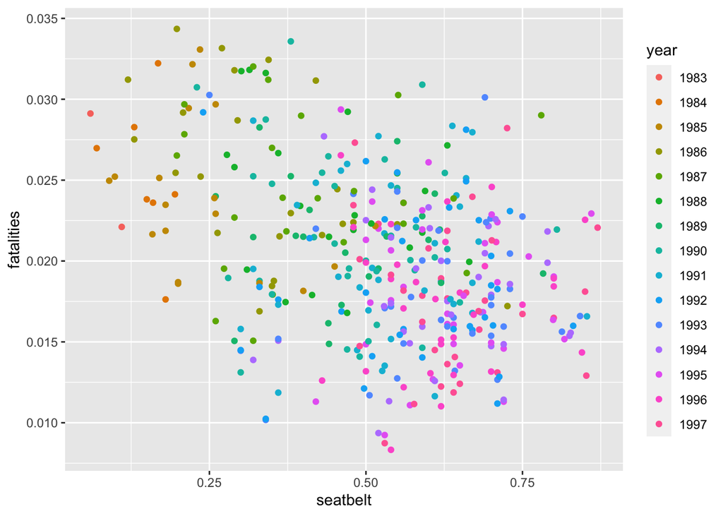

```r
data.noNa %>% ggplot(. , aes(x = seatbelt, y = fatalities, color = year)) +
  geom_point()
```

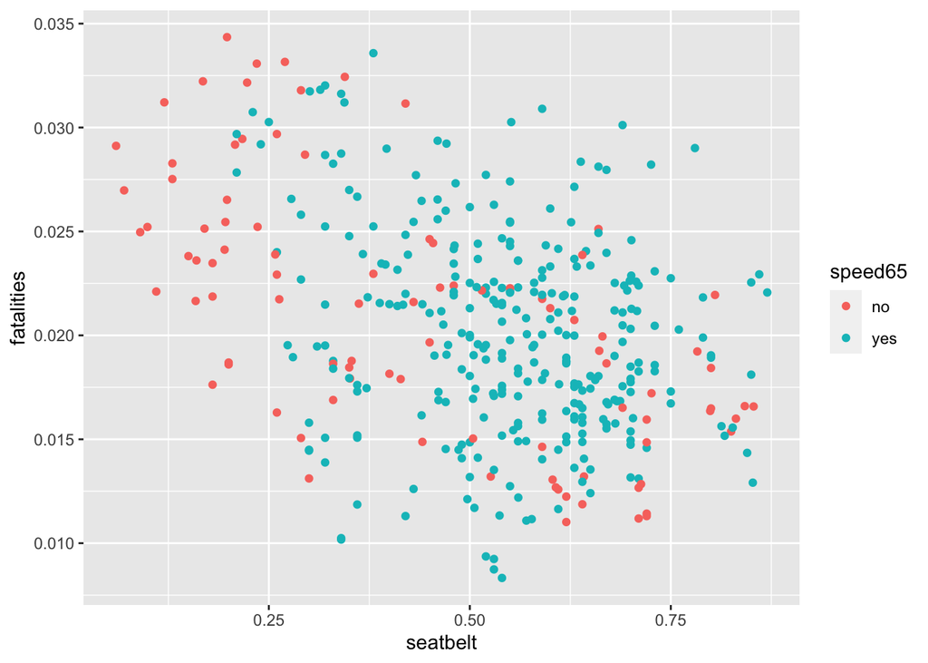

```r
data.noNa %>% ggplot(. , aes(x = seatbelt, y = fatalities, color = speed65)) +
  geom_point()
```

For the first plot, we see that the higher years tend to have more seatbelt usage and lower fatlities (bottom right of scatterplot) and the lower years tend to have lower seatbelt usage and higher fatalities (top left of scatter plot).

The second plot provides no more new information.

We test for an interaction between `seatbelt` and `year`

```r
anova(lm(fatalities ~ state + speed65 + seatbelt*year, data = data.noNa))
```

```
## Analysis of Variance Table
##
## Response: fatalities
##                Df    Sum Sq    Mean Sq  F value Pr(>F)
## state          34 0.0070114 0.00020622  70.3552 <2e-16 ***
## speed65         1 0.0011629 0.00116291 396.7484 <2e-16 ***
## seatbelt        1 0.0010606 0.00106056 361.8295 <2e-16 ***
## year           14 0.0006752 0.00004823  16.4535 <2e-16 ***
## seatbelt:year  14 0.0000248 0.00000177   0.6045 0.8613
## Residuals     330 0.0009673 0.00000293
## ---
## Signif. codes:  0 '***' 0.001 '**' 0.01 '*' 0.05 '.' 0.1 ' ' 1
```

As we can see, the interaction term is insignificant so we don’t include it. Our final model for the second model is:

$$fatalities \thicksim state + speed65 + seatbelt + year$$
For the `data.noNa` data

# diagnostic checking for our models

$\hd{Model 1}$

For our first model, which is now:
$$fatalities \thicksim state + year + income_c + I(income_c^2)$$
We check for heteroscedasticity and for linearity

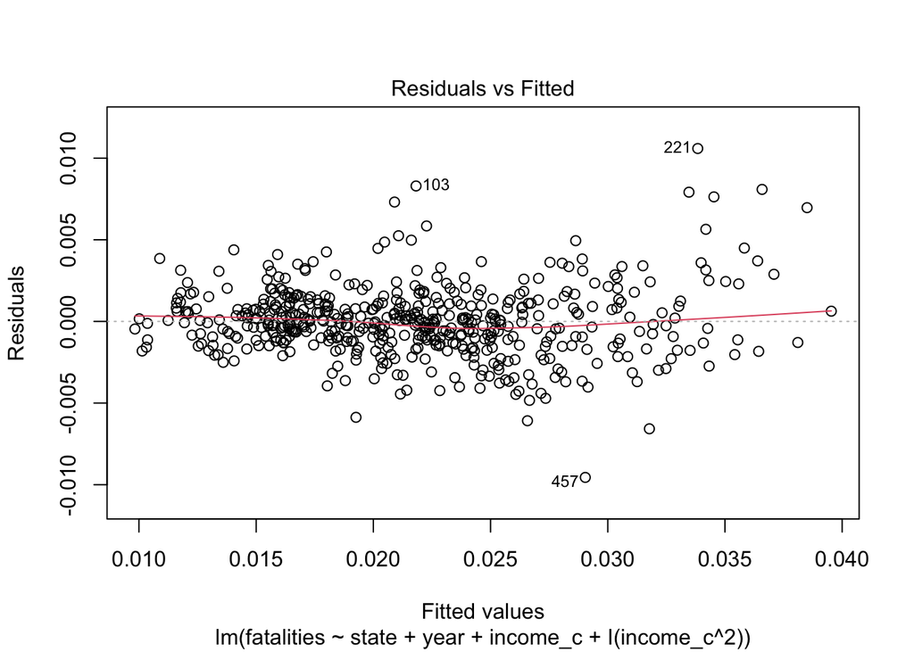

```r
plot(lm(fatalities ~ state + year + income_c + I(income_c^2), data = data_first_model), which = 1)
```

We see that since the constant variance assumption and linearity assumption seem to be satisfied.

We now check our normality assumption

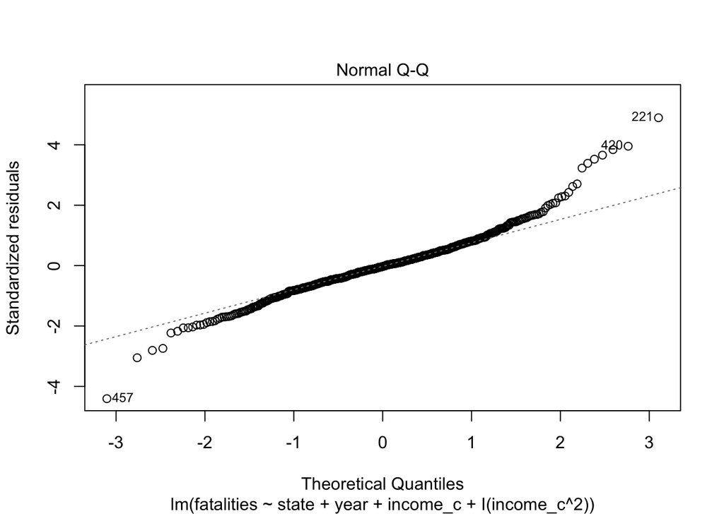

```r
plot(lm(fatalities ~ state + year + income_c + I(income_c^2), data = data_first_model), which = 2)
```

$\hd{Model 2}$

For our second model, which is now:
$$fatalities \thicksim state + year + seatbelt + speed65$$
We check for heteroscedasticity and for linearity

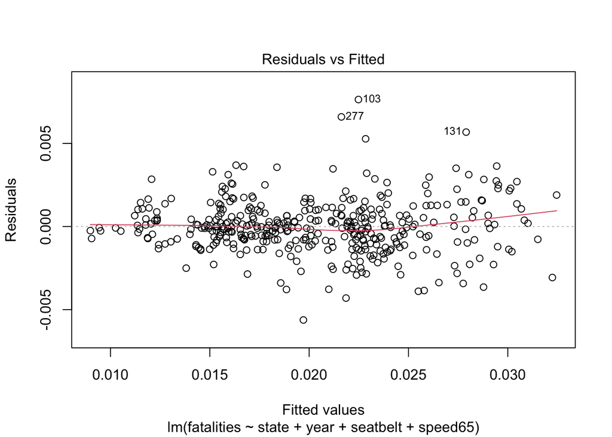

```r
plot(lm(fatalities ~ state + year + seatbelt + speed65, data = data.noNa), which = 1)
```

We see that since the constant variance assumption is okay. One could make the argument that it seems to be fanning out, but broadly speaking I do think the constant variance assumption is met. The linearity assumption seems to be satisfied!

We now check our normality assusmption

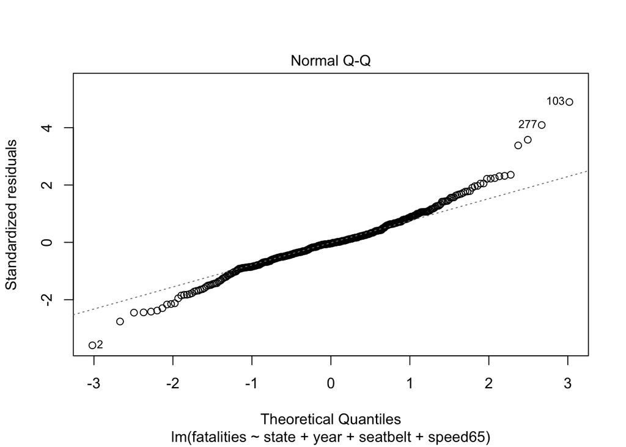

```r
plot(lm(fatalities ~ state + year + seatbelt + speed65, data = data.noNa), which = 2)
```

# High leverage, outliers and influential points

$\hd{Model 1}$

For our first model, which is now:
$$fatalities \thicksim state + year + income_c + I(income_c^2)$$

```r
model1 = lm(fatalities ~ state + year + income_c + I(income_c^2), data = data_first_model)
```

Where `income_c` is the mean centered version of the variables `income` we test for High leverage, outlier and influential points

$\hd{Outliers}$

Firstly we look at potential outliers by looking at the externally studentized residuals. We assign observation numbers so that we can keep track of the observation we are referring to.

```r
# number of observations
n = nrow(data_first_model)
# number of coefficients for our model
p = length(model1$coefficients)

student_resid_1 = rstudent(model1)
rst_df1 = data.frame(obs_num = 1:n, rst = student_resid_1)
```

1. The studentized residuals follow a $t$ distribution with $n - 1 -p = 472$ degrees of freedom
2. We compare the magnitude of the externally studentized residuals with the magnitude of the $1 - \alpha/(2n)$ quantile (bon-ferroni correction taken into account) and see whether any residuals are greater than such a quantile
3. We take $\alpha = 0.05$ as our significance level
4. We also look at the threshold of a studentized residual of greater than 3 as that could also indicate a potential outlier (reference: https://online.stat.psu.edu/stat462/node/247/)

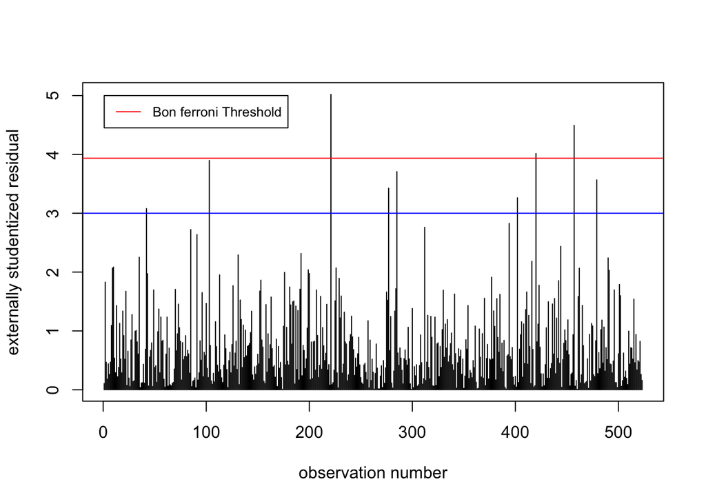

```r
# our threshold
threshold = qt(1 - 0.05/(2*n), df = n-p-1, lower.tail = TRUE)
# plot the threshold alongside the residual value of 3
plot(abs(rst_df1$rst), type = 'h', xlab = 'observation number', ylab = 'externally studentized residual')
abline(h = threshold, col = 'red')
abline(h = 3, col = 'blue')
legend(1, 5, legend = c('Bon ferroni Threshold'), col = c('red'), lty = 1, cex = 0.8)
```

```r
# see if the magnitude of any of our studentized residuals are greater than the threshold
rst_df1 %>% filter(abs(rst) > threshold) %>% arrange(desc(abs(rst)))
```

```
##     obs_num       rst
## 221     221  5.019210
## 457     457 -4.494983
## 420     420  4.015968
```

```r
rst_df1 %>% filter(abs(rst) > 3) %>% arrange(desc(abs(rst)))
```

```
##     obs_num       rst
## 221     221  5.019210
## 457     457 -4.494983
## 420     420  4.015968
## 103     103  3.896896
## 285     285  3.706949
## 479     479  3.566559
## 277     277  3.425792
## 402     402  3.262468
## 42       42 -3.078994
```

- We flag three observations: 221, 457 and 420 for having exceptionally high externally studentized residuals.
- Furthermore we flag a further six observations: 103, 285, 479, 277, 402 and 42 for having studentized residuals above 3

$\hd{High leverage}$

We use the `influence.measures()` command on our model to obtain values to do with leverage and influence:

```r
influence_measures_1 = influence.measures(model1)
influence_df_1 = data.frame(obs_num = 1:n, influence_measures_1$infmat, row.names = NULL)
```

We firstly look at leverage. To see the observations which have high leverage we:

1. Define the average leverage: $\bar{h} = \frac{p}{n}$
2. See which observations have hat value greater than $2\bar{h}$ or $3\bar{h}$

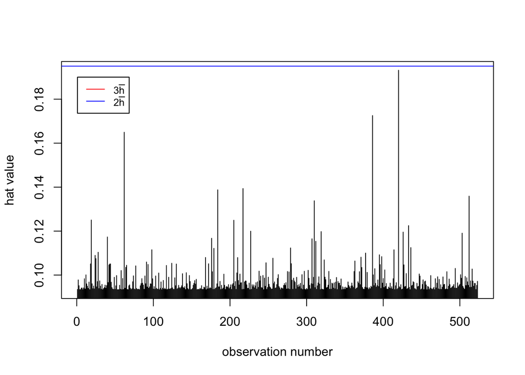

```r
h_bar = p/n
plot(influence_df_1$hat, type = 'h', xlab = 'observation number', ylab = 'hat value')
abline(h = 3*h_bar, col = 'red')
abline(h = 2*h_bar, col = 'blue')
# for the legend
three_h_bar = TeX(r'($3\bar{h}$)')
two_h_bar = TeX(r'($2\bar{h}$)')
legend(1, 0.19, legend = c(three_h_bar, two_h_bar), col = c('red', 'blue'), lty = c(1, 1), cex = c(0.8, 0.8))
```

We see that no observations are exactly greater than $2\bar{h}$ and especially $3\bar{h}$ but there seems to be three observations in particular which are relatively higher than the others:

```r
influence_df_1 %>% dplyr::select(obs_num, hat) %>% arrange(desc(hat)) %>% head(. , 8)
```

```
##   obs_num       hat
## 1     420 0.1931457
## 2     386 0.1725442
## 3      62 0.1649597
## 4     217 0.1393570
## 5     184 0.1387590
## 6     512 0.1358873
## 7     310 0.1337884
## 8      19 0.1250401
```

- These are observations: 420, 386 and 62
- Let’s see which observations these correspond to:

```r
data_first_model[c(62, 386, 420), ]
```

```
##     fatalities state year   income_c
## 62  0.01803969    DC 1997 17294.2849
## 386 0.01187307    CT 1997 17453.2849
## 420 0.04466945    AK 1983  -436.7151
```

```r
summary(data_first_model)
```

```
##    fatalities           state          year        income_c
##  Min.   :0.008327   AK     : 15   1983   : 35   Min.   :-10037.7
##  1st Qu.:0.017290   AL     : 15   1984   : 35   1st Qu.: -3855.2
##  Median :0.021353   AR     : 15   1985   : 35   Median :  -401.7
##  Mean   :0.021737   AZ     : 15   1986   : 35   Mean   :     0.0
##  3rd Qu.:0.025126   CA     : 15   1987   : 35   3rd Qu.:  3303.3
##  Max.   :0.045470   CO     : 15   1988   : 35   Max.   : 17453.3
##                     (Other):433   (Other):313
```

- We can see that observation 62 and 386 have high leverage due to having high centred income
- At first we cannot see why observation 420 would have such high leverage.
- However if we look back to our original data with all the covariates we see that it is because of the variable `age` and `miles`. This observation had the minimum age and relatively low miles value.

```r
summary(data)
```

```
##      state          year         miles          fatalities
##  AK     : 15   1983   : 35   Min.   :  3099   Min.   :0.008327
##  AL     : 15   1984   : 35   1st Qu.: 11441   1st Qu.:0.017290
##  AR     : 15   1985   : 35   Median : 27951   Median :0.021353
##  AZ     : 15   1986   : 35   Mean   : 40721   Mean   :0.021737
##  CA     : 15   1987   : 35   3rd Qu.: 51004   3rd Qu.:0.025126
##  CO     : 15   1988   : 35   Max.   :285612   Max.   :0.045470
##  (Other):433   (Other):313
##     seatbelt     speed65   speed70   drinkage  alcohol       income
##  Min.   :0.060   no :190   no :487   no : 56   no :476   Min.   : 8372
##  1st Qu.:0.412   yes:333   yes: 36   yes:467   yes: 47   1st Qu.:14554
##  Median :0.550                                           Median :18008
##  Mean   :0.523                                           Mean   :18410
##  3rd Qu.:0.641                                           3rd Qu.:21713
##  Max.   :0.870                                           Max.   :35863
##  NA's   :128
##       age             enforce
##  Min.   :28.23   no       :196
##  1st Qu.:34.37   primary  : 71
##  Median :35.40   secondary:256
##  Mean   :35.17
##  3rd Qu.:36.10
##  Max.   :39.17
##
```

```r
data[420, ]
```

```
##     state year miles fatalities seatbelt speed65 speed70 drinkage alcohol
## 420    AK 1983  3358 0.04466945       NA      no      no      yes      no
##     income      age enforce
## 420  17973 28.23497      no
```

$\hd{Model 2}$

For our second model, which is now:
$$fatalities \thicksim state + year + seatbelt + speed65$$

```r
model2 = lm(fatalities ~ state + year + seatbelt + speed65, data = data.noNa)
```

We test for High leverage, outliers and influential points

$\hd{Outliers}$

Firstly we look at potential outliers by looking at the externally studentized residuals. We assign observation numbers so that we can keep track of the observation we are referring to.

```r
# number of observations
n = nrow(data.noNa)
# number of coefficients for our model
p = length(model2$coefficients)
# redefine data.noNa so that it has observation number linked to it
data.noNa = data.noNa %>% mutate(obs_num = 1:n)

student_resid_2 = rstudent(model2)
rst_df2 = data.frame(obs_num = 1:n, rst = student_resid_2)
```

1. The studentized residuals follow a $t$ distribution with $n - 1 -p = 344$ degrees of freedom
2. We compare the magnitude of the externally studentized residuals with the magnitude of the $1 - \alpha/(2n)$ quantile (bon-ferroni correction taken into account) and see whether any residuals are greater than such a quantile
3. We take $\alpha = 0.05$ as our significance level
4. We also look at the threshold of a studentized residual of greater than 3 as that could also indicate a potential outlier (reference: https://online.stat.psu.edu/stat462/node/247/)

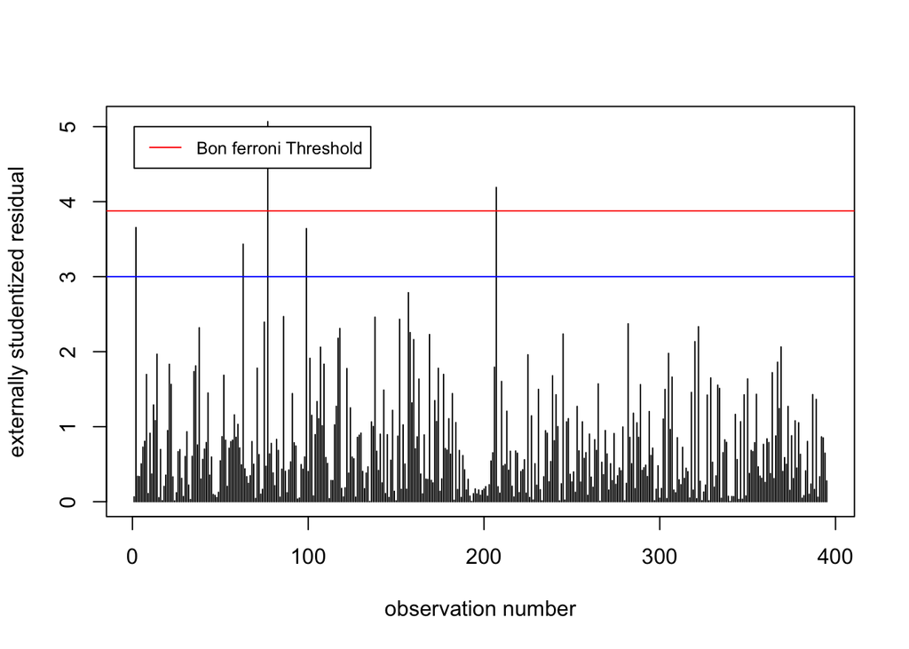

```r
# our threshold
threshold = qt(1 - 0.05/(2*n), df = n-p-1, lower.tail = TRUE)
# plot the threshold alongside the residual value of 3
plot(abs(rst_df2$rst), type = 'h', xlab = 'observation number', ylab = 'externally studentized residual')
abline(h = threshold, col = 'red')
abline(h = 3, col = 'blue')
legend(1, 5, legend = c('Bon ferroni Threshold'), col = c('red'), lty = 1, cex = 0.8)
```

```r
# see if the magnitude of any of our studentized residuals are greater than the threshold
rst_df2 %>% filter(abs(rst) > threshold) %>% arrange(desc(abs(rst)))
```

```
##     obs_num      rst
## 103      77 5.067130
## 277     207 4.189944
```

```r
rst_df2 %>% filter(abs(rst) > 3) %>% arrange(desc(abs(rst)))
```

```
##     obs_num       rst
## 103      77  5.067130
## 277     207  4.189944
## 2         2 -3.655489
## 131      99  3.641176
## 85       63  3.433231
```

$\hd{High leverage}$

We use the `influence.measures()` command on our model to obtain values to do with leverage and influence.

```r
influence_measures_2 = influence.measures(model2)
influence_df_2 = data.frame(obs_num = 1:n, influence_measures_2$infmat, row.names = NULL)
```

We firstly look at leverage. To see the observations which have high leverage we:

1. Define the average leverage: $\bar{h} = \frac{p}{n}$
2. See which observations have hat value greater than $2\bar{h}$ or $ 3{h}$

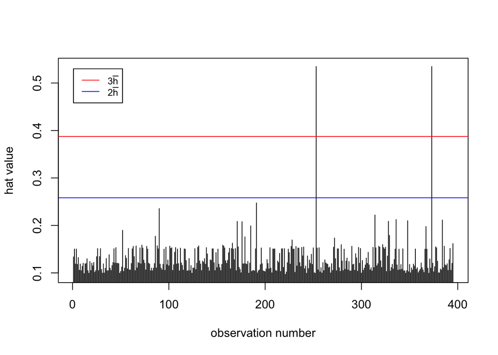

```r
h_bar = p/n
plot(influence_df_2$hat, type = 'h', xlab = 'observation number', ylab = 'hat value')
abline(h = 3*h_bar, col = 'red')
abline(h = 2*h_bar, col = 'blue')
# for the legend
three_h_bar = TeX(r'($3\bar{h}$)')
two_h_bar = TeX(r'($2\bar{h}$)')
legend(1, 0.53, legend = c(three_h_bar, two_h_bar), col = c('red', 'blue'), lty = c(1, 1), cex = c(0.8, 0.8))
```

We see that there are exactly 2 observations which have unusually hgih leverage.

```r
influence_df_2 %>% dplyr::select(obs_num, hat) %>% arrange(desc(hat)) %>% head(. , 8)
```

```
##   obs_num       hat
## 1     253 0.5347415
## 2     373 0.5347415
## 3     191 0.2475242
## 4      90 0.2355222
## 5     314 0.2219648
## 6     336 0.2125395
## 7     384 0.2113615
## 8     348 0.2099362
```

- These are observations: 253 and 373
- Let’s see which observations these correspond to:

```r
data.noNa %>% filter(obs_num %in% c(253, 373))
```

```
##   state year miles fatalities seatbelt speed65 speed70 drinkage alcohol income
## 1    KY 1983 26719 0.02911786     0.06      no      no      yes      no   9696
## 2    NE 1983 11534 0.02210855     0.11      no      no       no      no  11401
##        age enforce obs_num
## 1 34.01682      no     253
## 2 34.85776      no     373
```

```r
summary(data.noNa)
```

```
##      state          year         miles          fatalities
##  NE     : 15   1990   : 35   Min.   :  3316   Min.   :0.008327
##  AL     : 14   1991   : 35   1st Qu.: 12724   1st Qu.:0.016493
##  KY     : 14   1992   : 35   Median : 34003   Median :0.019895
##  MI     : 14   1993   : 35   Mean   : 45754   Mean   :0.020270
##  MT     : 14   1994   : 35   3rd Qu.: 59378   3rd Qu.:0.023536
##  NJ     : 14   1995   : 35   Max.   :285612   Max.   :0.034349
##  (Other):310   (Other):185
##     seatbelt     speed65   speed70   drinkage  alcohol       income
##  Min.   :0.060   no : 93   no :359   no : 14   no :350   Min.   : 9696
##  1st Qu.:0.412   yes:302   yes: 36   yes:381   yes: 45   1st Qu.:16460
##  Median :0.550                                           Median :19290
##  Mean   :0.523                                           Mean   :19754
##  3rd Qu.:0.641                                           3rd Qu.:22862
##  Max.   :0.870                                           Max.   :35863
##
##       age             enforce       obs_num
##  Min.   :29.59   no       : 89   Min.   :  1.0
##  1st Qu.:34.66   primary  : 63   1st Qu.: 99.5
##  Median :35.56   secondary:243   Median :198.0
##  Mean   :35.47                   Mean   :198.0
##  3rd Qu.:36.26                   3rd Qu.:296.5
##  Max.   :39.17                   Max.   :395.0
##
```

- We can see that observation 253 has high leverage because it has minimum income and minimum seatbelt value
- We can see that observation 373 has high leverage because it has relatively low income and relatively low seatbelt value

$\hd{influential points}$

We now go on to check which observations are influential and why they would be influential. We check this through the metrics of `dffit` and `cook.d` (that is, dffits and cooks distance).

```r
influence_df_2 %>% arrange(desc(abs(dffit))) %>% dplyr::select(obs_num, dffit) %>% head(10)
```

```
##    obs_num     dffit
## 1       77  2.178017
## 2        2 -1.537938
## 3       63  1.475375
## 4      207  1.398803
## 5       99  1.390256
## 6      373 -1.362611
## 7      253  1.362611
## 8      157 -1.200606
## 9       86 -1.145813
## 10     322  1.017162
```

```r
influence_df_2 %>% arrange(desc(abs(cook.d))) %>% dplyr::select(obs_num, cook.d) %>% head(10)
```

```
##    obs_num     cook.d
## 1       77 0.08678926
## 2        2 0.04476864
## 3       63 0.04138334
## 4      207 0.03660404
## 5       99 0.03659425
## 6      373 0.03634102
## 7      253 0.03634102
## 8      157 0.02771856
## 9       86 0.02536726
## 10     322 0.02002782
```

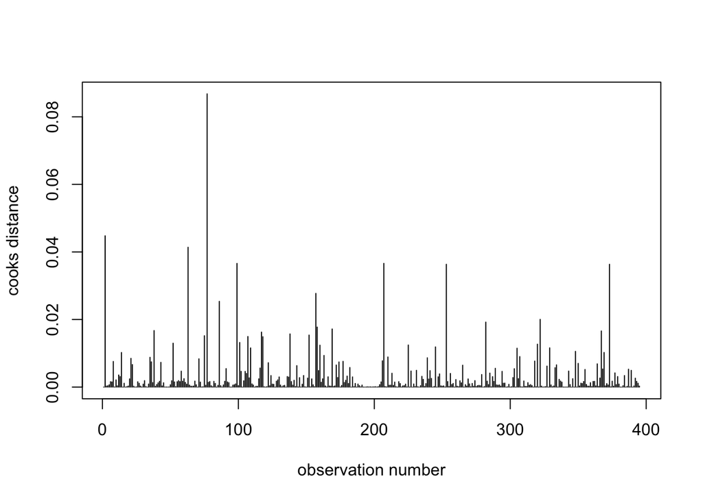

```r
plot(abs(influence_df_2$cook.d), type = 'h', xlab = 'observation number', ylab = 'cooks distance')
```

Therefore to summarise:

- We seem to have one influential point. That is observation 77 becuase it has exceptionally high externally studentized residual